# Investigation of Prescription Flows between General Practices and Boots Pharmacies via Spatial Interaction Modeling Techniques

## Modelling flows above 100 items per year

```r
# Selecting rows withmore then 100 items
GFM <- GFL[which(GFL$Items > 100), ]
```

```r
# defining models
# 19 - Unconstrained model
minfirst <- glm(Items ~ log(GP_Items_PY) + log(BO_I_PY) + distance , na.action = na.exclude, family = poisson(link = "log"), data = GFM)

# 20 - Unconstrained model with covariates
minsecond <- glm(Items ~ log(GP_Items_PY) + log(BO_I_PY) + distance + dist_centre + GP_Flag +  GP_Partners + GP_pop_tot + GP_eth_prop + BO_day_pop + BO_Format + BO_py_boots_comp + BO_NHS_Desc + BO_py_competitors , na.action = na.exclude, family = poisson(link = "log"), data = GFM)

# 21 - Production constrained model
minthird <- glm(Items ~ GP_ODS  + log(BO_I_PY) +  distance
               , na.action = na.exclude, family = poisson(link = "log"), data = GFM)

# 22 - Attraction constrained model
minfourth <- glm(Items ~ Ph_ODS +log(GP_Items_PY)  +  distance
                , na.action = na.exclude, family = poisson(link = "log"), data = GFM)

# 23 - Doubly constrained model
minfifth <- glm(Items ~  GP_ODS + Ph_ODS + distance
              , na.action = na.exclude, family = poisson(link = "log"), data = GFM)

# 24 - Mixed effect model
# minrandom <- glmer(Items ~ GP_ODS + log(BO_I_PY) +  distance + (1|dist_centre) ,  family = poisson(link = "log"), data = GFM@data)
```

```r
# R2, AIC, RMSE
r2s <- data.frame(model=c( 'minfirst', 'minsecond', 'minthird','minfourth', 'minfifth'),
                      R2_logit=c(
                              R2logit(Items, minfirst),
                              R2logit(Items, minsecond),
                             R2logit(Items, minthird),
                             R2logit(Items, minfourth),
                             R2logit(Items, minfifth)))
r2s
```

```
##       model  R2_logit
## 1  minfirst 0.5685590
## 2 minsecond 0.6094512
## 3  minthird 0.7306940
## 4 minfourth 0.6207625
## 5  minfifth 0.7861684
```

```r
AIC(minfirst, minsecond, minthird, minfourth, minfifth)
```

```
##            df     AIC
## minfirst    4 5583622
## minsecond  19 5055782
## minthird  251 3491141
## minfourth  63 4909853
## minfifth  310 2775150
```

```r
rmses <- data.frame(model=c( 'minfirst', 'minsecond', 'minthird','minfourth', 'minfifth'),
                      RMSE=c(
                              rmse(GFM$Items, minfirst$fitted.values),
                              rmse(GFM$Items, minsecond$fitted.values),
                             rmse(GFM$Items, minthird$fitted.values),
                             rmse(GFM$Items, minfourth$fitted.values),
                             rmse(GFM$Items, minfifth$fitted.values)

                           )
                      )
rmses
```

```
##       model     RMSE
## 1  minfirst 6007.818
## 2 minsecond 5459.293
## 3  minthird 4628.792
## 4 minfourth 5403.588
## 5  minfifth 3823.588
```

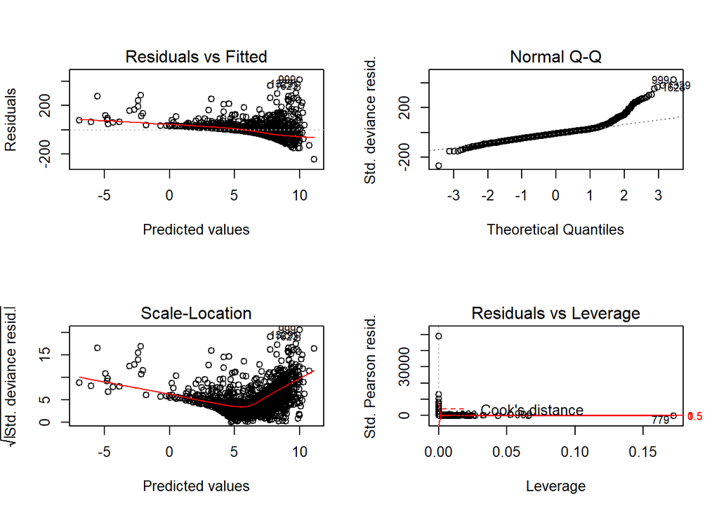

```
## $mfrow
## [1] 1 1
```

```r
# model diagnostics
# 19 - Unconstrained model
print(
par(mfrow=c(2,2)),
plot(minfirst)
)
```

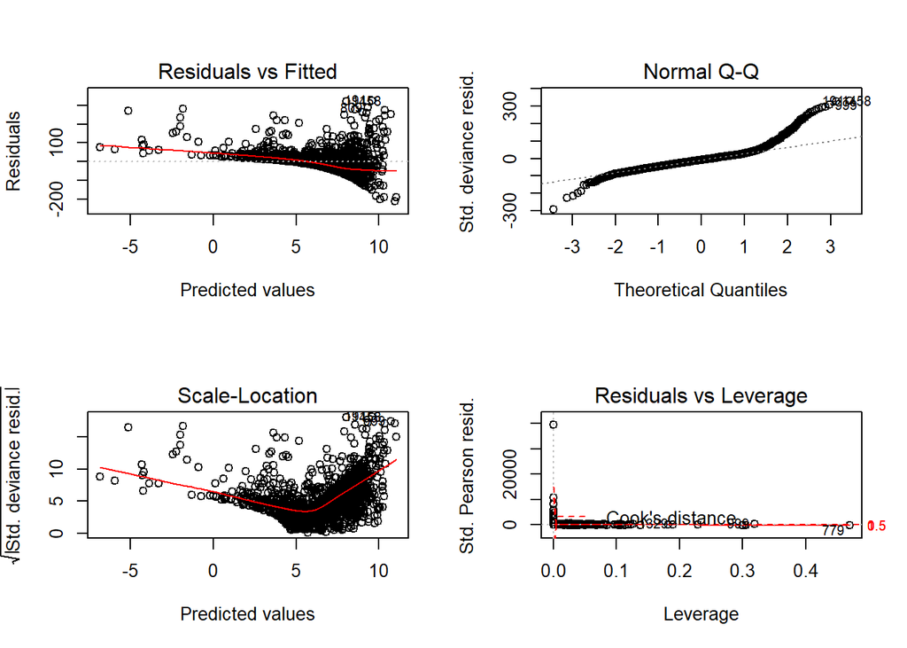

```
## $mfrow
## [1] 2 2
```

```r
# 20 - Unconstrained model with covariates
print(
par(mfrow=c(2,2)),
plot(minsecond)
)
```

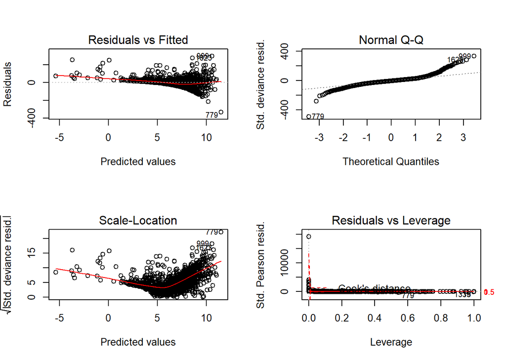

```
## $mfrow
## [1] 2 2
```

```r
# 21 - Production constrained model
print(
par(mfrow=c(2,2)),
plot(minthird)
)
```

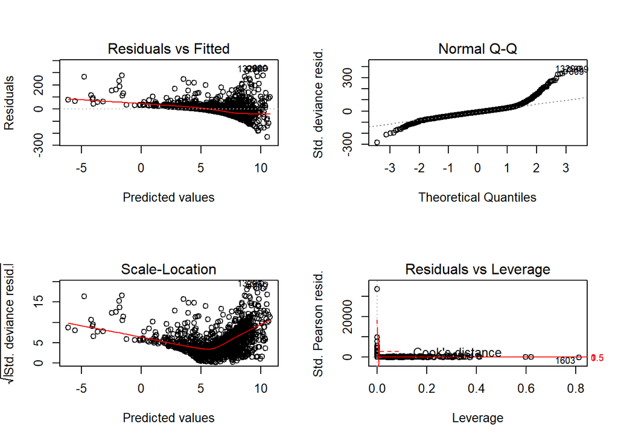

```
## $mfrow
## [1] 2 2
```

```r
# 22 - Attraction constrained model
print(
par(mfrow=c(2,2)),
plot(minfourth)
)
```

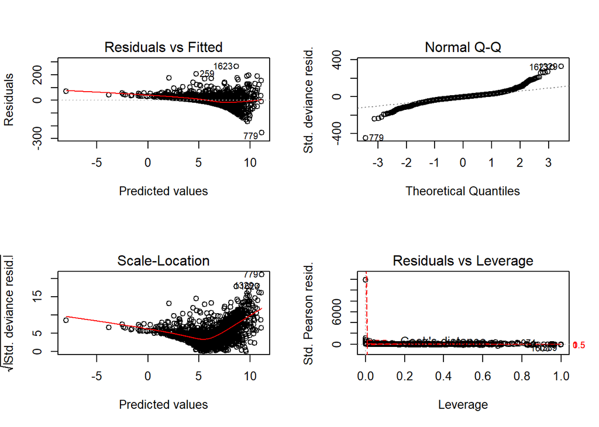

```
## $mfrow
## [1] 2 2
```

```r
# 23 - Doubly constrained model
print(
par(mfrow=c(2,2)),
plot(minfifth)
)
```

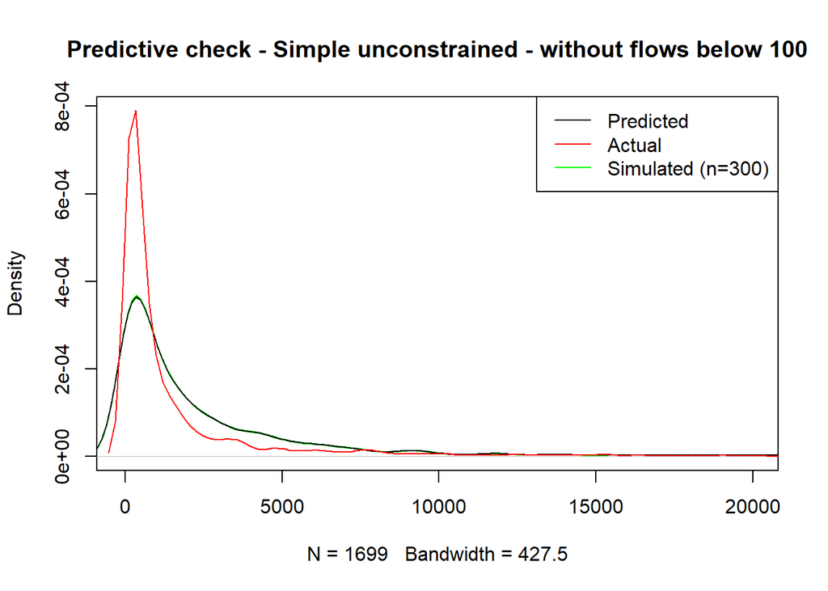

```r
# Predictive plot
# 19 - Unconstrained model
plot(density(minfirst$fitted.values),
     xlim=c(-100, 20000),
     ylim=c(0, max(c(
                  max(density(minfirst$fitted.values)$y),
                  max(density(GFM$Items)$y)
                  )
               )
      ),
     col='white',
     main='')
# Loop for realizations
for(i in 1:300){
  tmp_y <- generate_draw_poi(minfirst)
  lines(density(tmp_y),
        col='green',
        lwd=0.5
        )
}
lines(density(minfirst$fitted.values),
      col='black',
      main='')
lines(density(GFM$Items),
      col='red',
      main='')
legend('topright',
       c('Predicted', 'Actual', 'Simulated (n=300)'),
       col=c('black', 'red', 'green'),
       lwd=1)
title(main="Predictive check - Simple unconstrained - without flows below 100")
```

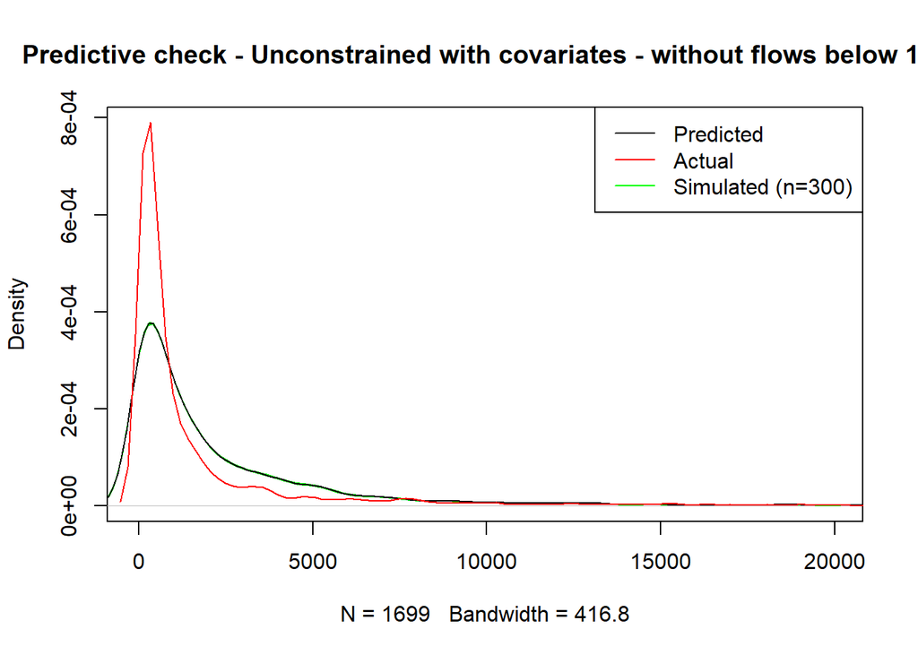

```r
# 20 - Unconstrained model with covariates
plot(density(minsecond$fitted.values),
     xlim=c(-100, 20000),
     ylim=c(0, max(c(
                  max(density(minsecond$fitted.values)$y),
                  max(density(GFM$Items)$y)
                  )
               )
      ),
     col='white',
     main='')
# Loop for realizations
for(i in 1:300){
  tmp_y <- generate_draw_poi(minsecond)
  lines(density(tmp_y),
        col='green',
        lwd=0.5
        )
}
lines(density(minsecond$fitted.values),
      col='black',
      main='')
lines(density(GFM$Items),
      col='red',
      main='')
legend('topright',
       c('Predicted', 'Actual', 'Simulated (n=300)'),
       col=c('black', 'red', 'green'),
       lwd=1)
title(main="Predictive check - Unconstrained with covariates - without flows below 100")
```

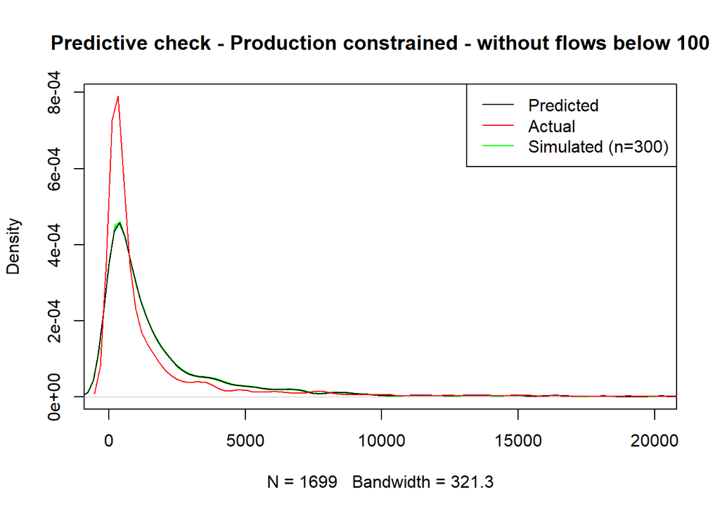

```r
# 21 - Production constrained model
plot(density(minthird$fitted.values),
     xlim=c(-100, 20000),
     ylim=c(0, max(c(
                  max(density(minthird$fitted.values)$y),
                  max(density(GFM$Items)$y)
                  )
               )
      ),
     col='white',
     main='')
# Loop for realizations
for(i in 1:300){
  tmp_y <- generate_draw_poi(minthird)
  lines(density(tmp_y),
        col='green',
        lwd=0.5
        )
}
lines(density(minthird$fitted.values),
      col='black',
      main='')
lines(density(GFM$Items),
      col='red',
      main='')
legend('topright',
       c('Predicted', 'Actual', 'Simulated (n=300)'),
       col=c('black', 'red', 'green'),
       lwd=1)
title(main="Predictive check - Production constrained - without flows below 100")
```

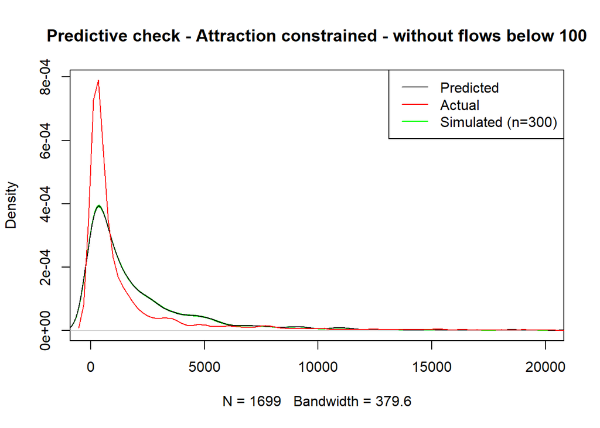

```r
# 22 - Attraction constrained model
plot(density(minfourth$fitted.values),
     xlim=c(-100, 20000),
     ylim=c(0, max(c(
                  max(density(minfourth$fitted.values)$y),
                  max(density(GFM$Items)$y)
                  )
               )
      ),
     col='white',
     main='')
# Loop for realizations
for(i in 1:300){
  tmp_y <- generate_draw_poi(minfourth)
  lines(density(tmp_y),
        col='green',
        lwd=0.5
        )
}
lines(density(minfourth$fitted.values),
      col='black',
      main='')
lines(density(GFM$Items),
      col='red',
      main='')
legend('topright',
       c('Predicted', 'Actual', 'Simulated (n=300)'),
       col=c('black', 'red', 'green'),
       lwd=1)
title(main="Predictive check - Attraction constrained - without flows below 100")
```

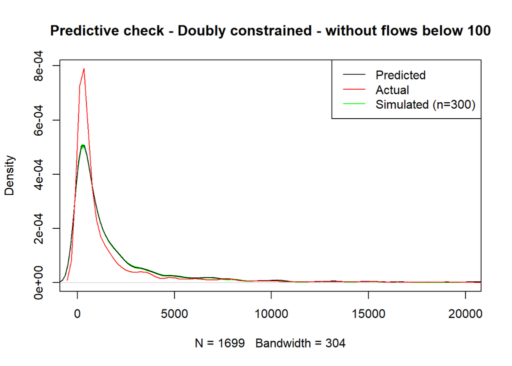

```r
# 23 - Doubly constrained model
plot(density(minfifth$fitted.values),
     xlim=c(-100, 20000),
     ylim=c(0, max(c(
                  max(density(minfifth$fitted.values)$y),
                  max(density(GFM$Items)$y)
                  )
               )
      ),
     col='white',
     main='')
# Loop for realizations
for(i in 1:300){
  tmp_y <- generate_draw_poi(minfifth)
  lines(density(tmp_y),
        col='green',
        lwd=0.5
        )
}
lines(density(minfifth$fitted.values),
      col='black',
      main='')
lines(density(GFM$Items),
      col='red',
      main='')
legend('topright',
       c('Predicted', 'Actual', 'Simulated (n=300)'),
       col=c('black', 'red', 'green'),
       lwd=1)
title(main="Predictive check - Doubly constrained - without flows below 100")
```

## Modelling flows above the mean Item from all flows

```r
# generate mean flow
Meanflow <- mean(GFL$Items)
# selest flows above 771 Items
GFX <- GFL[which(GFL$Items > Meanflow), ]
```

```r
# defining models
# 25 - Unconstrained model
maxfirst <- glm(Items ~ log(GP_Items_PY) + log(BO_I_PY) + distance , na.action = na.exclude, family = poisson(link = "log"), data = GFX)

# 26 - Unconstrained model with covariates
maxsecond <- glm(Items ~ log(GP_Items_PY) + log(BO_I_PY) + distance + dist_centre + GP_Flag +  GP_Partners + GP_pop_tot + GP_eth_prop + BO_day_pop + BO_Format + BO_py_boots_comp + BO_NHS_Desc + BO_py_competitors , na.action = na.exclude, family = poisson(link = "log"), data = GFX)

# 27 - Production constrained model
maxthird <- glm(Items ~ GP_ODS  + log(BO_I_PY) +  distance
               , na.action = na.exclude, family = poisson(link = "log"), data = GFX)

# 28 - Attraction constrained model
maxfourth <- glm(Items ~ Ph_ODS +log(GP_Items_PY)  +  distance
                , na.action = na.exclude, family = poisson(link = "log"), data = GFX)

# 29 - Doubly constrained model
maxfifth <- glm(Items ~  GP_ODS + Ph_ODS + distance
              , na.action = na.exclude, family = poisson(link = "log"), data = GFX)

# 30 - Mixed effect model
# maxrandom <- glmer(Items ~ GP_ODS + log(BO_I_PY) +  distance + (1|dist_centre) ,  family = poisson(link = "log"), data = GFX@data)
```

```r
# R2, AIc, RMSE
r2s <- data.frame(model=c( 'maxfirst', 'maxsecond', 'maxthird','maxfourth', 'maxfifth'),
                      R2_logit=c(
                              R2logit(Items, maxfirst),
                              R2logit(Items, maxsecond),
                             R2logit(Items, maxthird),
                             R2logit(Items, maxfourth),
                             R2logit(Items, maxfifth)))
r2s
```

```
##       model  R2_logit
## 1  maxfirst 0.3067590
## 2 maxsecond 0.4906845
## 3  maxthird 0.7731783
## 4 maxfourth 0.5630870
## 5  maxfifth 0.8627494
```

```r
AIC(maxfirst, maxsecond, maxthird, maxfourth, maxfifth)
```

```
##            df       AIC
## maxfirst    4 2663498.3
## maxsecond  19 1957801.0
## maxthird  182  874190.9
## maxfourth  62 1680077.0
## maxfifth  232  530604.3
```

```r
rmses <- data.frame(model=c( 'maxfirst', 'maxsecond', 'maxthird','maxfourth', 'maxfifth'),
                      RMSE=c(
                              rmse(GFX$Items, maxfirst$fitted.values),
                              rmse(GFX$Items, maxsecond$fitted.values),
                             rmse(GFX$Items, maxthird$fitted.values),
                             rmse(GFX$Items, maxfourth$fitted.values),
                             rmse(GFX$Items, maxfifth$fitted.values)

                           )
                      )
rmses
```

```
##       model      RMSE
## 1  maxfirst 12604.005
## 2 maxsecond 10198.120
## 3  maxthird  7795.689
## 4 maxfourth  9671.322
## 5  maxfifth  5107.474
```

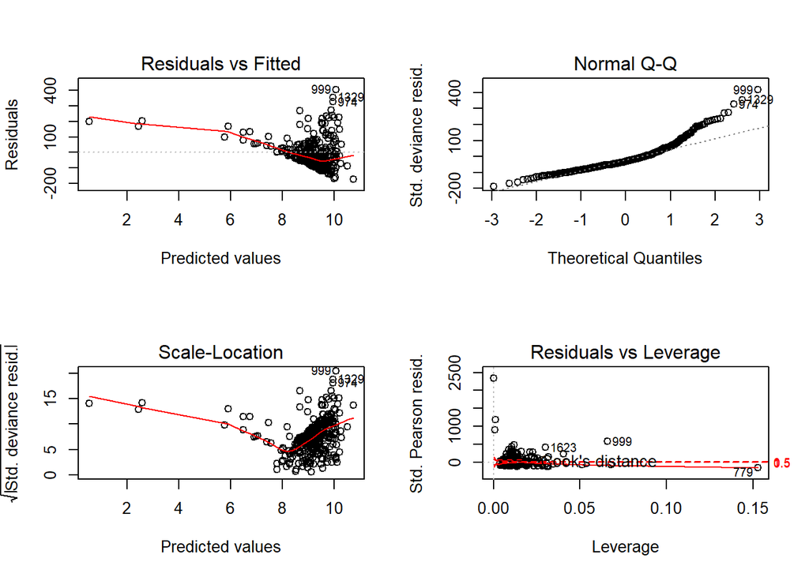

```
## $mfrow
## [1] 1 1
```

```r
# model diagnostics
# 25 - Unconstrained model
print(
par(mfrow=c(2,2)),
plot(maxfirst)
)
```

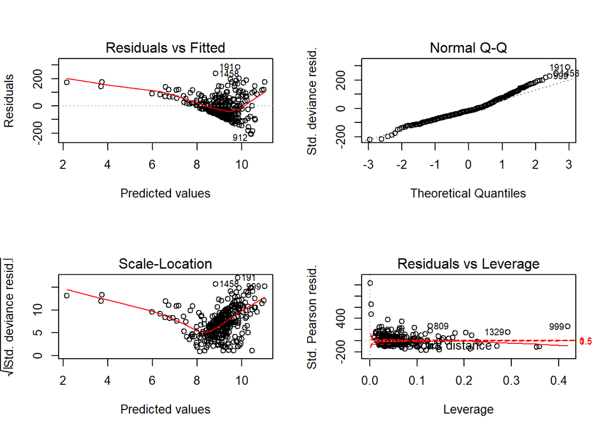

```
## $mfrow
## [1] 2 2
```

```r
# 26 - Unconstrained model with covariates
print(
par(mfrow=c(2,2)),
plot(maxsecond)
)
```

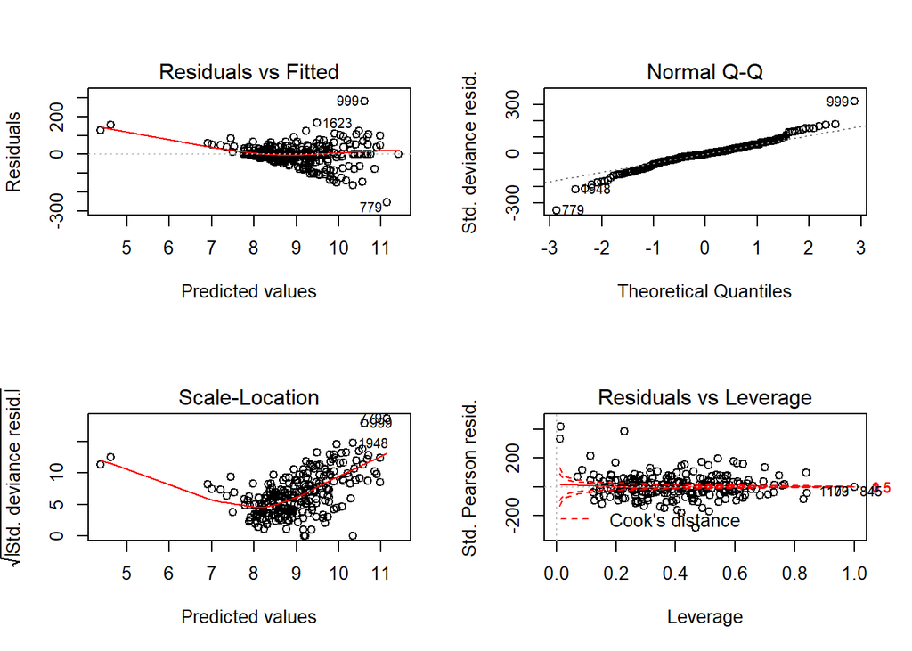

```
## $mfrow
## [1] 2 2
```

```r
# 27 - Production constrained model
print(
par(mfrow=c(2,2)),
plot(maxthird)
)
```

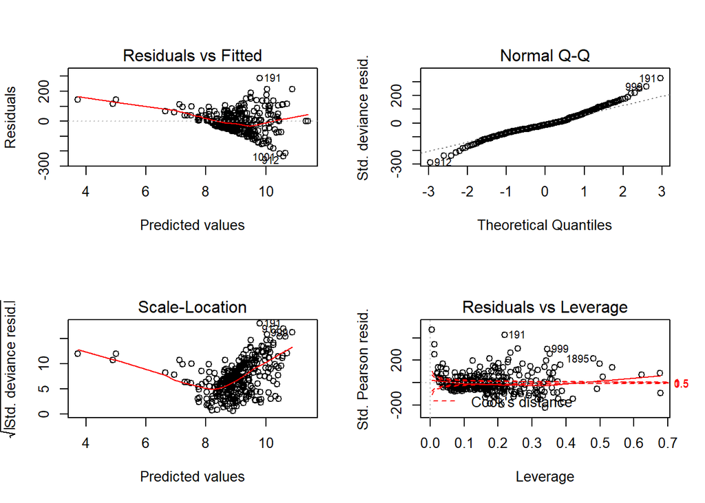

```
## $mfrow
## [1] 2 2
```

```r
# 28 - Attraction constrained model
print(
par(mfrow=c(2,2)),
plot(maxfourth)
)
```

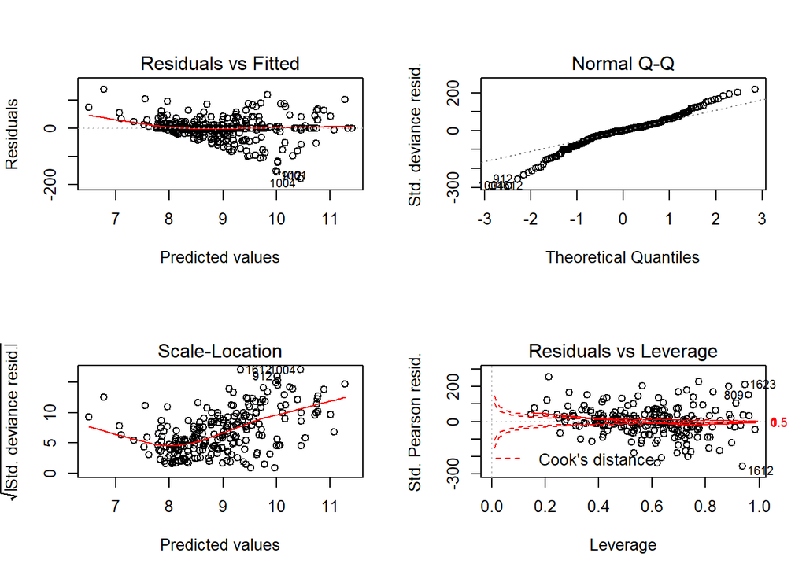

```
## $mfrow
## [1] 2 2
```

```r
# 29 - Doubly constrained model
print(
par(mfrow=c(2,2)),
plot(maxfifth)
)
```

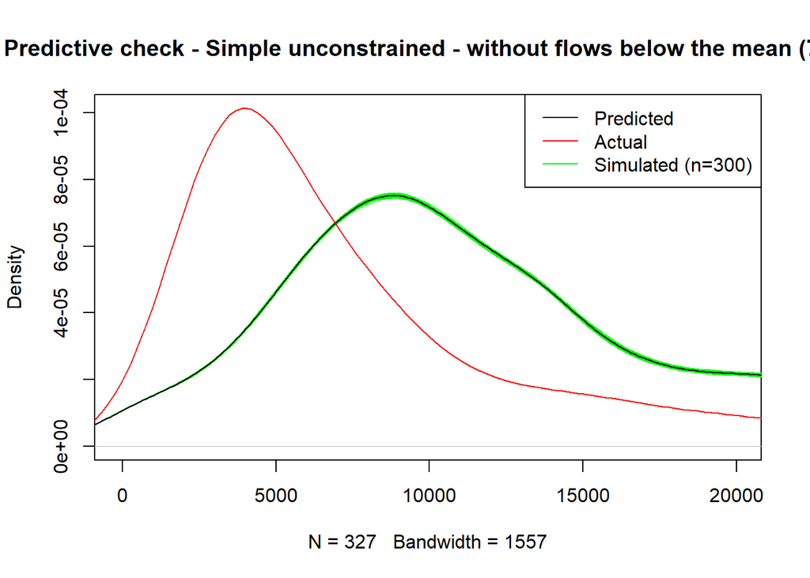

```r
# predictive check
# 25 - Unconstrained model
plot(density(maxfirst$fitted.values),
     xlim=c(-100, 20000),
     ylim=c(0, max(c(
                  max(density(maxfirst$fitted.values)$y),
                  max(density(GFX$Items)$y)
                  )
               )
      ),
     col='white',
     main='')
# Loop for realizations
for(i in 1:300){
  tmp_y <- generate_draw_poi(maxfirst)
  lines(density(tmp_y),
        col='green',
        lwd=0.5
        )
}
lines(density(maxfirst$fitted.values),
      col='black',
      main='')
lines(density(GFX$Items),
      col='red',
      main='')
legend('topright',
       c('Predicted', 'Actual', 'Simulated (n=300)'),
       col=c('black', 'red', 'green'),
       lwd=1)
title(main="Predictive check - Simple unconstrained - without flows below the mean (771)")
```

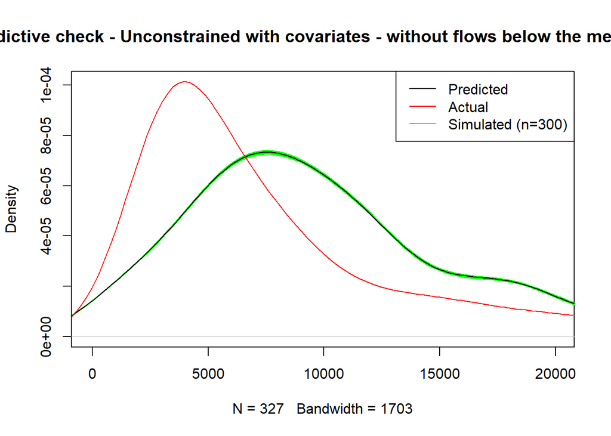

```r
# 26 - Unconstrained model with covariates
plot(density(maxsecond$fitted.values),
     xlim=c(-100, 20000),
     ylim=c(0, max(c(
                  max(density(maxsecond$fitted.values)$y),
                  max(density(GFX$Items)$y)
                  )
               )
      ),
     col='white',
     main='')
# Loop for realizations
for(i in 1:300){
  tmp_y <- generate_draw_poi(maxsecond)
  lines(density(tmp_y),
        col='green',
        lwd=0.5
        )
}
lines(density(maxsecond$fitted.values),
      col='black',
      main='')
lines(density(GFX$Items),
      col='red',
      main='')
legend('topright',
       c('Predicted', 'Actual', 'Simulated (n=300)'),
       col=c('black', 'red', 'green'),
       lwd=1)
title(main="Predictive check - Unconstrained with covariates - without flows below the mean (771)")
```

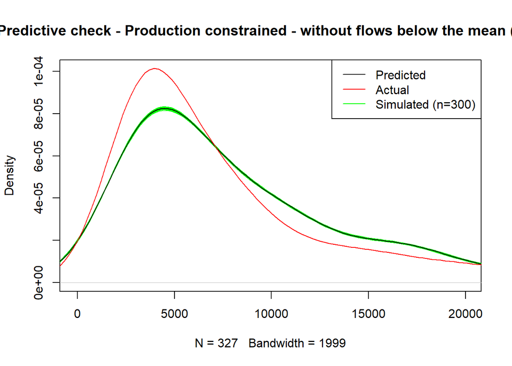

```r
# 27 - Production constrained model
plot(density(maxthird$fitted.values),
     xlim=c(-100, 20000),
     ylim=c(0, max(c(
                  max(density(maxthird$fitted.values)$y),
                  max(density(GFX$Items)$y)
                  )
               )
      ),
     col='white',
     main='')
# Loop for realizations
for(i in 1:300){
  tmp_y <- generate_draw_poi(maxthird)
  lines(density(tmp_y),
        col='green',
        lwd=0.5
        )
}
lines(density(maxthird$fitted.values),
      col='black',
      main='')
lines(density(GFX$Items),
      col='red',
      main='')
legend('topright',
       c('Predicted', 'Actual', 'Simulated (n=300)'),
       col=c('black', 'red', 'green'),
       lwd=1)
title(main="Predictive check - Production constrained - without flows below the mean (771)")
```

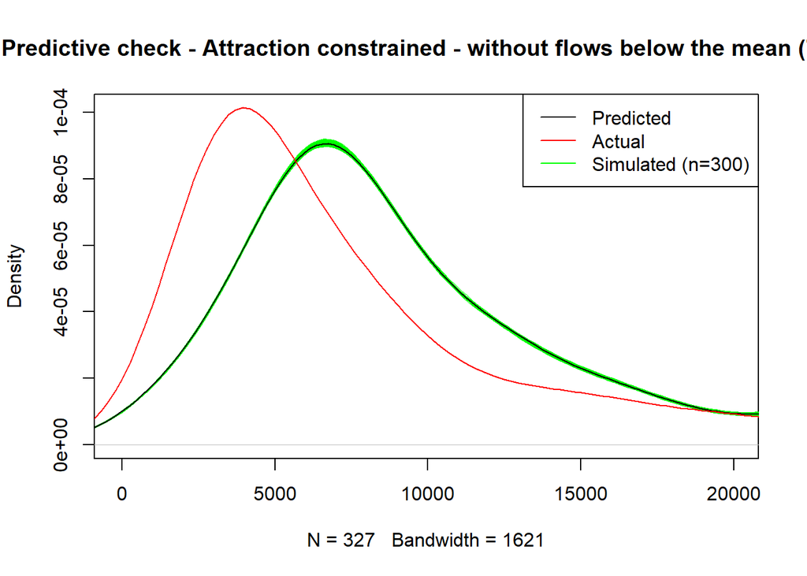

```r
# 28 - Attraction constrained model
plot(density(maxfourth$fitted.values),
     xlim=c(-100, 20000),
     ylim=c(0, max(c(
                  max(density(maxfourth$fitted.values)$y),
                  max(density(GFX$Items)$y)
                  )
               )
      ),
     col='white',
     main='')
# Loop for realizations
for(i in 1:300){
  tmp_y <- generate_draw_poi(maxfourth)
  lines(density(tmp_y),
        col='green',
        lwd=0.5
        )
}
lines(density(maxfourth$fitted.values),
      col='black',
      main='')
lines(density(GFX$Items),
      col='red',
      main='')
legend('topright',
       c('Predicted', 'Actual', 'Simulated (n=300)'),
       col=c('black', 'red', 'green'),
       lwd=1)
title(main="Predictive check - Attraction constrained - without flows below the mean (771)")
```

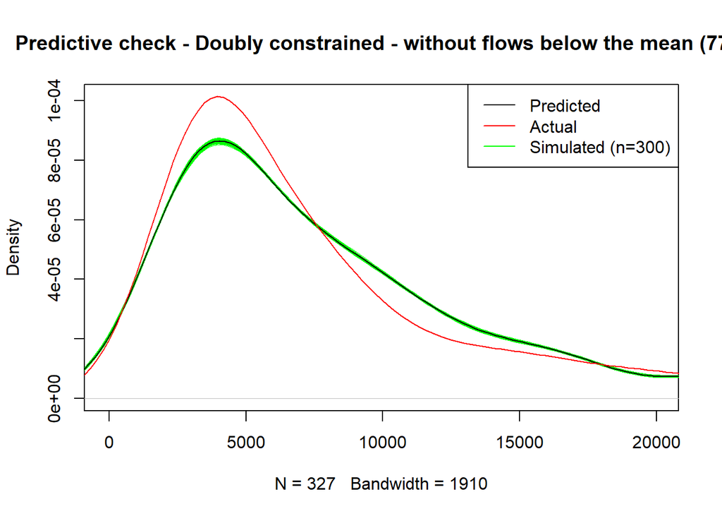

```r
# 29 - Doubly constrained model
plot(density(maxfifth$fitted.values),
     xlim=c(-100, 20000),
     ylim=c(0, max(c(
                  max(density(maxfifth$fitted.values)$y),
                  max(density(GFX$Items)$y)
                  )
               )
      ),
     col='white',
     main='')
# Loop for realizations
for(i in 1:300){
  tmp_y <- generate_draw_poi(maxfifth)
  lines(density(tmp_y),
        col='green',
        lwd=0.5
        )
}
lines(density(maxfifth$fitted.values),
      col='black',
      main='')
lines(density(GFX$Items),
      col='red',
      main='')
legend('topright',
       c('Predicted', 'Actual', 'Simulated (n=300)'),
       col=c('black', 'red', 'green'),
       lwd=1)
title(main="Predictive check - Doubly constrained - without flows below the mean (771)")
```

## Modelling flows within walking distance 1600m

```r
# Defining flows within 1600 distance
GFW <- GFL[which(GFL$distance < 1600), ]
```

```r
# defining models
# 31 - Unconstrained model
walkfirst <- glm(Items ~ log(GP_Items_PY) + log(BO_I_PY) + distance , na.action = na.exclude, family = poisson(link = "log"), data = GFW)

# 32 - Unconstrained model with covariates
walksecond <- glm(Items ~ log(GP_Items_PY) + log(BO_I_PY) + distance + dist_centre + GP_Flag +  GP_Partners + GP_pop_tot + GP_eth_prop + BO_day_pop + BO_Format + BO_py_boots_comp + BO_NHS_Desc + BO_py_competitors , na.action = na.exclude, family = poisson(link = "log"), data = GFW)

# 33 - Production constrained model
walkthird <- glm(Items ~ GP_ODS  + log(BO_I_PY) +  distance  , na.action = na.exclude, family = poisson(link = "log"), data = GFW)

# 34 - Attraction constrained model
walkfourth <- glm(Items ~ Ph_ODS +log(GP_Items_PY)  +  distance , na.action = na.exclude, family = poisson(link = "log"), data = GFW)

# 35 - Doubly constrained model
walkfifth <- glm(Items ~  GP_ODS + Ph_ODS + distance, na.action = na.exclude, family = poisson(link = "log"), data = GFW)
```

```r
# R2, AIC, RMSE
r2s <- data.frame(model=c( 'walkfirst', 'walksecond', 'walkthird','walkfourth', 'walkfifth'),
                      R2_logit=c(
                              R2logit(Items, walkfirst),
                              R2logit(Items, walksecond),
                             R2logit(Items, walkthird),
                             R2logit(Items, walkfourth),
                             R2logit(Items, walkfifth)))
r2s
```

```
##        model  R2_logit
## 1  walkfirst 0.6367896
## 2 walksecond 0.7129416
## 3  walkthird 0.8960081
## 4 walkfourth 0.7546239
## 5  walkfifth 0.9406020
```

```r
AIC(walkfirst, walksecond, walkthird, walkfourth, walkfifth)
```

```
##             df       AIC
## walkfirst    4 1649404.2
## walksecond  19 1304295.2
## walkthird  184  474924.3
## walkfourth  62 1115467.0
## walkfifth  223  272892.5
```

```r
rmses <- data.frame(model=c( 'walkfirst', 'walksecond', 'walkthird','walkfourth', 'walkfifth'),
                      RMSE=c(
                              rmse(GFW$Items, walkfirst$fitted.values),
                              rmse(GFW$Items, walksecond$fitted.values),
                             rmse(GFW$Items, walkthird$fitted.values),
                             rmse(GFW$Items, walkfourth$fitted.values),
                             rmse(GFW$Items, walkfifth$fitted.values)

                           )
                      )
rmses
```

```
##        model     RMSE
## 1  walkfirst 9221.107
## 2 walksecond 7900.820
## 3  walkthird 4109.071
## 4 walkfourth 7122.337
## 5  walkfifth 3105.091
```

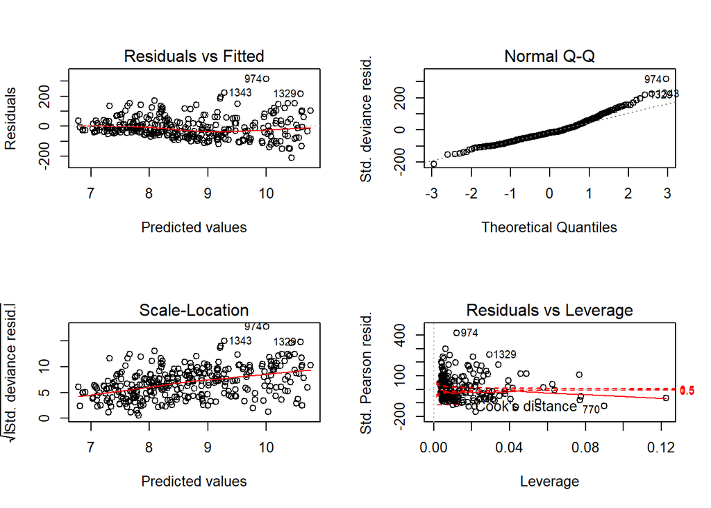

```
## $mfrow
## [1] 1 1
```

```r
# model diagnostics
# 31 - Unconstrained model
print(
par(mfrow=c(2,2)),
plot(walkfirst)
)
```

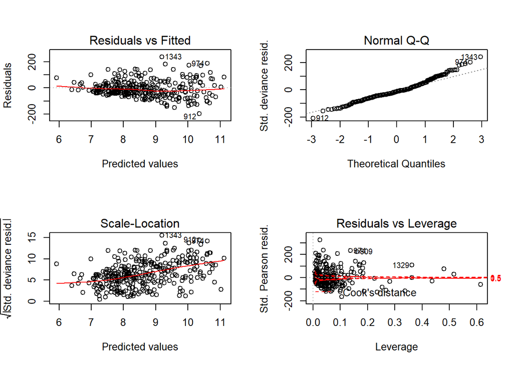

```
## $mfrow
## [1] 2 2
```

```r
# 32 - Unconstrained model with covariates
print(
par(mfrow=c(2,2)),
plot(walksecond)
)
```

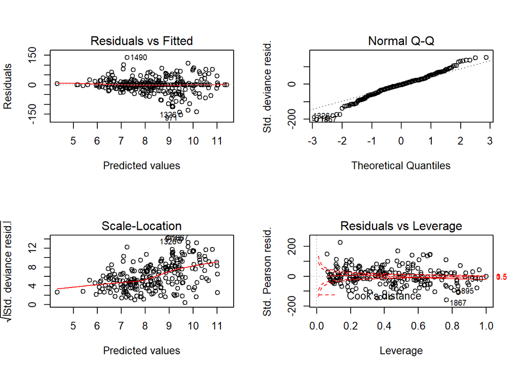

```
## $mfrow
## [1] 2 2
```

```r
# 33 - Production constrained model
print(
par(mfrow=c(2,2)),
plot(walkthird)
)
```

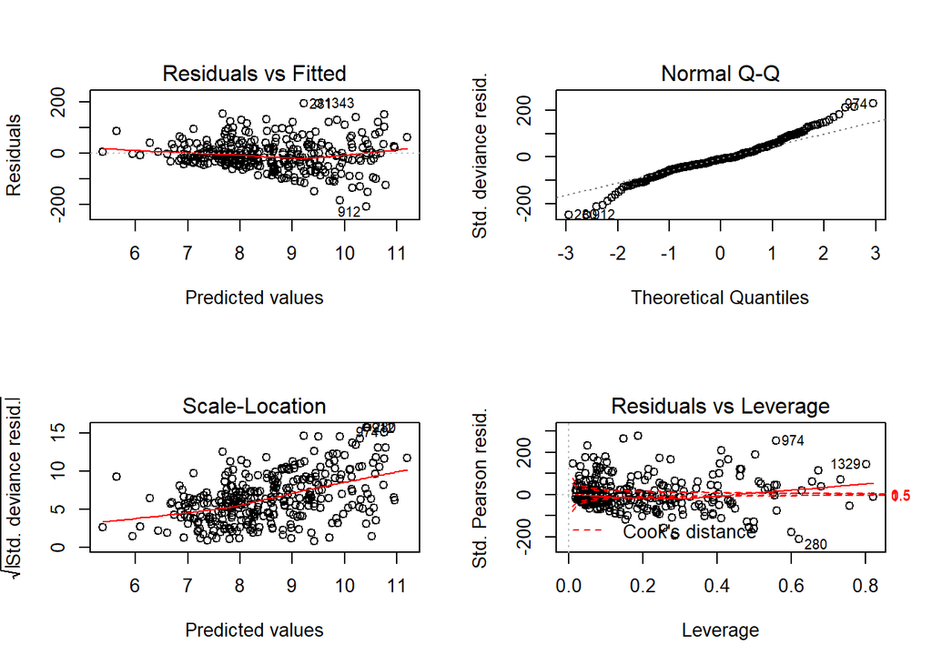

```
## $mfrow
## [1] 2 2
```

```r
# 34 - Attraction constrained model
print(
par(mfrow=c(2,2)),
plot(walkfourth)
)
```

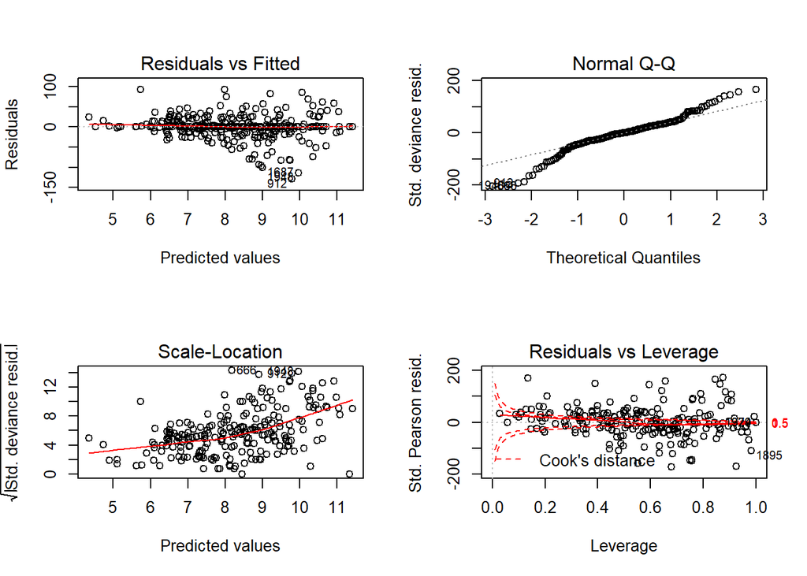

```
## $mfrow
## [1] 2 2
```

```r
# 35 - Doubly constrained model
print(
par(mfrow=c(2,2)),
plot(walkfifth)
)
```

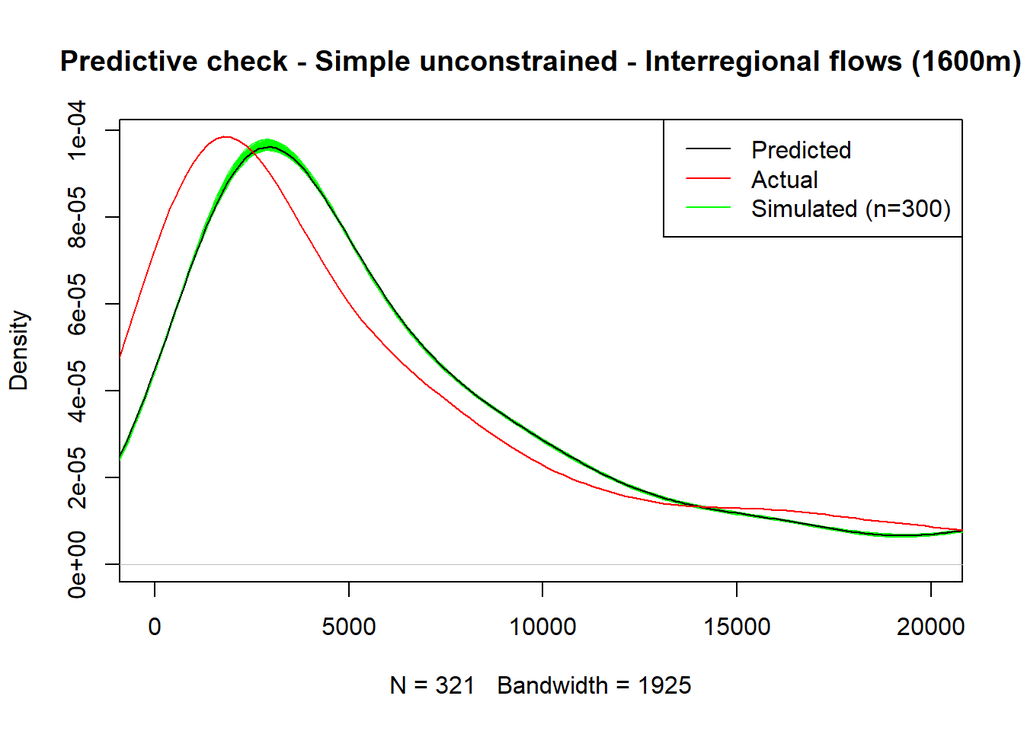

```r
# predictive check
# 31 - Unconstrained model
plot(density(walkfirst$fitted.values),
     xlim=c(-100, 20000),
     ylim=c(0, max(c(
                  max(density(walkfirst$fitted.values)$y),
                  max(density(GFW$Items)$y)
                  )
               )
      ),
     col='white',
     main='')
# Loop for realizations
for(i in 1:300){
  tmp_y <- generate_draw_poi(walkfirst)
  lines(density(tmp_y),
        col='green',
        lwd=0.5
        )
}
lines(density(walkfirst$fitted.values),
      col='black',
      main='')
lines(density(GFW$Items),
      col='red',
      main='')
legend('topright',
       c('Predicted', 'Actual', 'Simulated (n=300)'),
       col=c('black', 'red', 'green'),
       lwd=1)
title(main="Predictive check - Simple unconstrained - Interregional flows (1600m)")
```

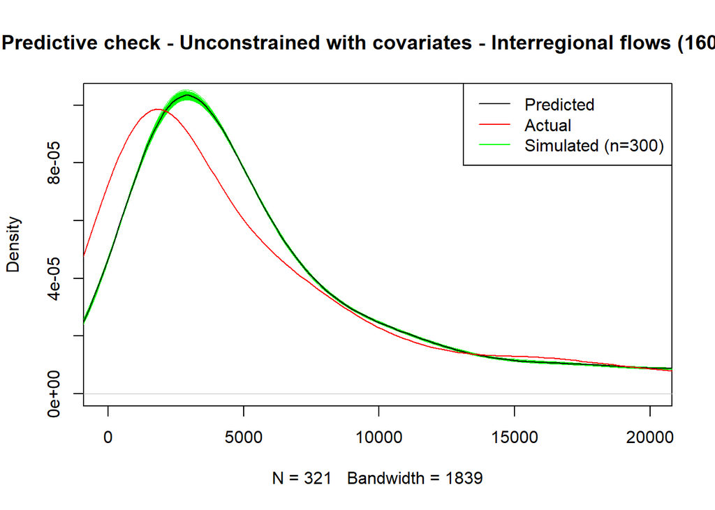

```r
# 32 - Unconstrained model with covariates
plot(density(walksecond$fitted.values),
     xlim=c(-100, 20000),
     ylim=c(0, max(c(
                  max(density(walksecond$fitted.values)$y),
                  max(density(GFW$Items)$y)
                  )
               )
      ),
     col='white',
     main='')
# Loop for realizations
for(i in 1:300){
  tmp_y <- generate_draw_poi(walksecond)
  lines(density(tmp_y),
        col='green',
        lwd=0.5
        )
}
lines(density(walksecond$fitted.values),
      col='black',
      main='')
lines(density(GFW$Items),
      col='red',
      main='')
legend('topright',
       c('Predicted', 'Actual', 'Simulated (n=300)'),
       col=c('black', 'red', 'green'),
       lwd=1)
title(main="Predictive check - Unconstrained with covariates - Interregional flows (1600m)")
```

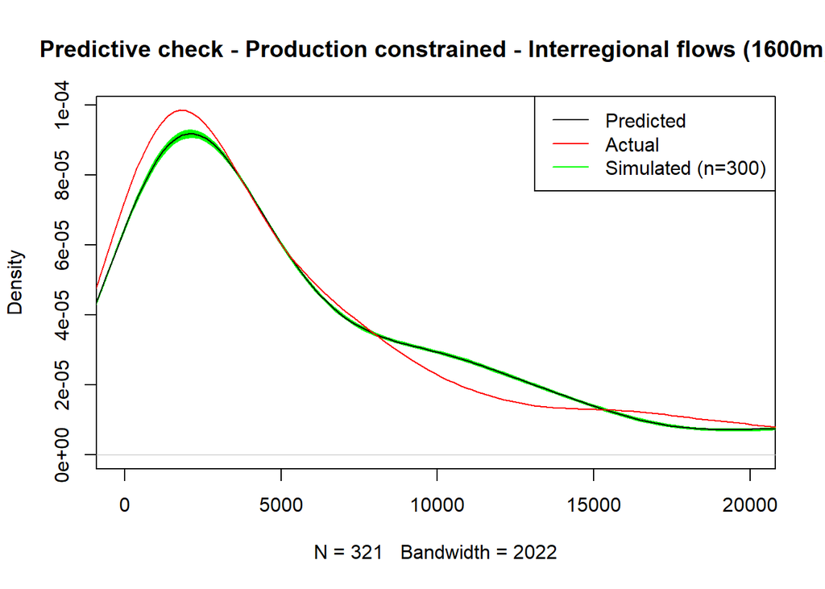

```r
# 33 - Production constrained model
plot(density(walkthird$fitted.values),
     xlim=c(-100, 20000),
     ylim=c(0, max(c(
                  max(density(walkthird$fitted.values)$y),
                  max(density(GFW$Items)$y)
                  )
               )
      ),
     col='white',
     main='')
# Loop for realizations
for(i in 1:300){
  tmp_y <- generate_draw_poi(walkthird)
  lines(density(tmp_y),
        col='green',
        lwd=0.5
        )
}
lines(density(walkthird$fitted.values),
      col='black',
      main='')
lines(density(GFW$Items),
      col='red',
      main='')
legend('topright',
       c('Predicted', 'Actual', 'Simulated (n=300)'),
       col=c('black', 'red', 'green'),
       lwd=1)
title(main="Predictive check - Production constrained - Interregional flows (1600m)")
```

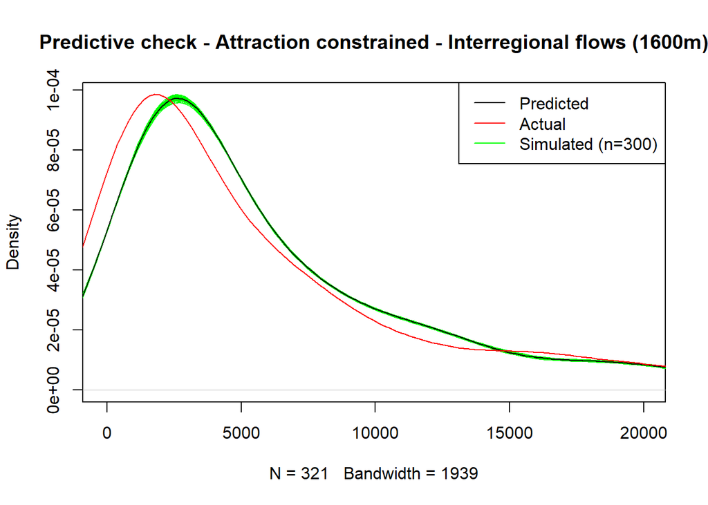

```r
# 34 - Attraction constrained model
plot(density(walkfourth$fitted.values),
     xlim=c(-100, 20000),
     ylim=c(0, max(c(
                  max(density(walkfourth$fitted.values)$y),
                  max(density(GFW$Items)$y)
                  )
               )
      ),
     col='white',
     main='')
# Loop for realizations
for(i in 1:300){
  tmp_y <- generate_draw_poi(walkfourth)
  lines(density(tmp_y),
        col='green',
        lwd=0.5
        )
}
lines(density(walkfourth$fitted.values),
      col='black',
      main='')
lines(density(GFW$Items),
      col='red',
      main='')
legend('topright',
       c('Predicted', 'Actual', 'Simulated (n=300)'),
       col=c('black', 'red', 'green'),
       lwd=1)
title(main="Predictive check - Attraction constrained - Interregional flows (1600m)")
```

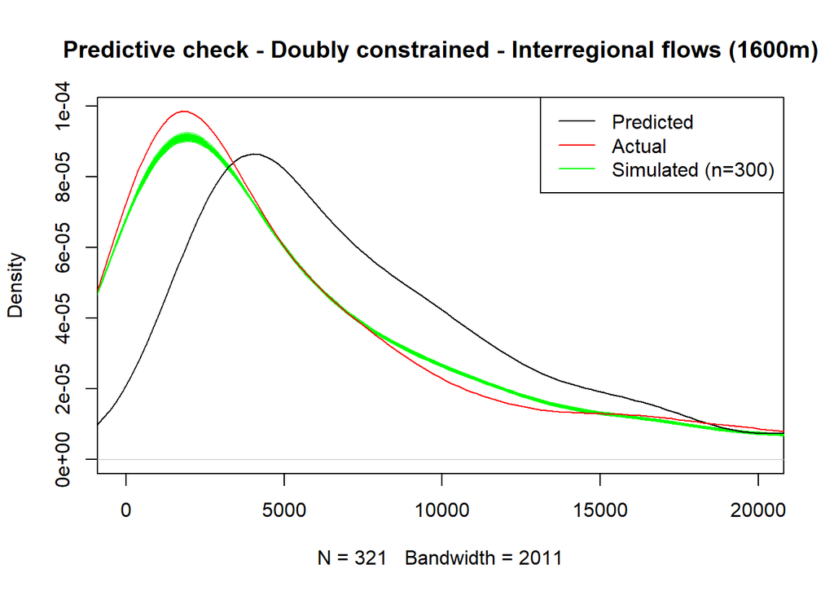

```r
# 35 - Doubly constrained model
plot(density(walkfifth$fitted.values),
     xlim=c(-100, 20000),
     ylim=c(0, max(c(
                  max(density(walkfifth$fitted.values)$y),
                  max(density(GFW$Items)$y)
                  )
               )
      ),
     col='white',
     main='')
# Loop for realizations
for(i in 1:300){
  tmp_y <- generate_draw_poi(walkfifth)
  lines(density(tmp_y),
        col='green',
        lwd=0.5
        )
}
lines(density(maxfifth$fitted.values),
      col='black',
      main='')
lines(density(GFW$Items),
      col='red',
      main='')
legend('topright',
       c('Predicted', 'Actual', 'Simulated (n=300)'),
       col=c('black', 'red', 'green'),
       lwd=1)
title(main="Predictive check - Doubly constrained - Interregional flows (1600m)")
```

# Export the estimates from model

Here is example of how the extract the coefficient estimates from the model, link them to our GP and pharmacy point data and export like a shapefile.

The coefficient could be easily visualized in R, Python or other platform such as QGis, depends on personal preferences.

```r
# save the coefs to a dataframe
coefs800 <- data.frame(coef(summary(intthird)))
coefs800GP <- coefs800[2:108,]
coefs800PH <- coefs800[109:123,]

# extract ODS code
coefs800GP$ID <- rownames(coefs800GP)
coefs800PH$ID <- rownames(coefs800PH)

coefs800GP$GP_ODS <- as.character(substring(coefs800GP$ID, 7))
coefs800PH$Ph_ODS <- as.character(substring(coefs800PH$ID, 7))

#merge with
cutgp8 <- merge(A_gps, coefs800GP, by='GP_ODS', all.y=T)
cutph8 <- merge(A_boots, coefs800PH, by='Ph_ODS', all.y=T)

#export
writeOGR(obj=cutgp8, dsn="E:/Dissertation/arc", layer="800fifth_GP", driver="ESRI Shapefile")
writeOGR(obj=cutph8, dsn="E:/Dissertation/arc", layer="800fifth_PH", driver="ESRI Shapefile")
```

# Final thoughts

Constrained spatial interaction models are significantly more efficient then any gravity models or traditional catchment profile regressions. The approach allows us to find a deficiency in the spatial interaction between the GP’s and pharmacies, however, this is very much dependent on two asumptions applied in the modelling process.

1. It is important to order the data according to what’s the purpose of the modeling. The model assumes that the first row of the data is ‘the best’ or ‘ideal’ flow that the others are compared with, therefor our model assumes that the best performing flow has the most prescribtions but its lenght is more than 2 km. Changing this assumption and placing a flow with less prescribtions but lenght of less than 2 meters, significantly chnage the result. Although this might seem to be a better for the purposes of the analysis, such a manipulation usually leads to misinterpretation and model’s overfitting.
2. The model does not account for any general difference between different types of pharmacies or GP’s that have generaly different character such as pharmacy sizes or GP size. For example General Practice with only one GP will obviously going to have naturally lower performance than practice with 8 practicioners. Accordingly, Boots pharmacy defined as High street pharmacy will have naturally different character of the flows than retail park pharmacy or local pharmacy. Runnig model selecting just flows within the classification and comparing the result to result from modelling all pharmacies could reval hidden pattern of flow efficiency.

For any questions or inquires, contact me on haska.lenka@gmail.com